# AGN_present

## Adversarial Generative Networks in PyTorch: a full code walkthrough

```python
from imports import *
```

```python
torch.cuda.is_available()
```

```
True
```

```python
torch.cuda.set_device(0)
```

```python
torch.cuda.current_device()
```

```
0
```

## Read in Eyeglass Frame Training Data for GAN

```python
PATH = Path('data/')
IMG_PATH = PATH/'eyeglasses'
CSV_PATH = PATH/'files.csv'
TMP_PATH = PATH/'tmp'
TMP_PATH.mkdir(exist_ok=True)
```

`files.csv` is a `.csv` file where column 1 is all of the filenames and column 2 are the classes

- we can optionally create a `files_sample.csv` file that contains a percentage of the data and leave some out for validation
- in this case `files_sample.csv` is just a copy of the original file

```python
files = PATH.glob('eyeglasses/*.png')

with CSV_PATH.open('w') as fo:
    for f in files: fo.write(f'{f.relative_to(IMG_PATH)},0\n')

CSV_PATH = PATH/'files_sample.csv'
files = PATH.glob('eyeglasses/*.png')

with CSV_PATH.open('w') as fo:
    for f in files:
        #if np.random.random()<0.1:
        fo.write(f'{f.relative_to(IMG_PATH)},1\n')
```

```python
fnames,y,classes = csv_source('eyeglasses', CSV_PATH, skip_header=True)
```

```python
val_idxs = get_cv_idxs(len(fnames))
((val_fnames,trn_fnames),(val_y,trn_y)) = split_by_idx(val_idxs, np.array(fnames), y)
```

```python
trn = (trn_fnames,trn_y)
val = (val_fnames,val_y)
```

Create a `Dataset` class that inherits from PyTorch `Dataset` class and pulls our eyeglass training data

```python
class EyeglassesDataset(Dataset):
    """Eyeglasses dataset."""

    def __init__(self, csv_file, root_dir, transform=None):
        """
        Args:
            csv_file (string): Path to the csv file with labels.
            root_dir (string): Directory with all the images.
            transform (callable, optional): Optional transform to be applied
                on a sample.
        """
        self.label = pd.read_csv(csv_file)
        self.root_dir = root_dir
        self.transform = transform

    def __len__(self):
        return len(self.label)

    def __getitem__(self, idx):
        img_name = os.path.join(self.root_dir,
                                self.label.iloc[idx, 0])
        image = io.imread(img_name)
        sample = image

        if self.transform:
            sample = self.transform(sample)

        return sample
```

```python
ngpu = 1
```

```python
device = torch.device("cuda:0" if (torch.cuda.is_available() and ngpu > 0) else "cpu")
```

Initialize our `EyeglassesDataset` object with some transformations

```python
tensor_dataset = EyeglassesDataset(csv_file='data/files_sample.csv',
                                           root_dir='data/eyeglasses/',
                                           transform=transforms.Compose([
                                               transforms.ToPILImage(),
                                               transforms.Resize(160),
                                               transforms.ToTensor(),
                                               Normalize(mean=(0.5, 0.5, 0.5), std=(0.5, 0.5, 0.5))
                                               #transforms.Normalize((0.5, 0.5, 0.5), (0.5, 0.5, 0.5))
                                           ]))
```

```python
dataloader_test = DataLoader(tensor_dataset, batch_size=4, shuffle=True, num_workers=2)
```

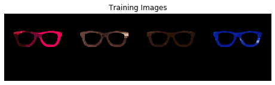

```python
real_batch = next(iter(dataloader_test))
plt.figure(figsize=(8,8))
plt.axis("off")
plt.title("Training Images")
plt.imshow(np.transpose(utils.make_grid(real_batch.to(device)[:64], padding=2, normalize=True).cpu(),(1,2,0)))
```

## Pre-Train GAN Models

```python
class Generator(nn.Module):
    def __init__(self, ngpu):
        super(Generator, self).__init__()
        self.ngpu = ngpu
        self.main = nn.Sequential(
            # input is Z, going into a convolution
            nn.ConvTranspose2d( nz, ngf * 8, 4, 1, 0, bias=False),
            nn.BatchNorm2d(ngf * 8),
            nn.ReLU(True),
            # state size. (ngf*8) x 4 x 4
            nn.ConvTranspose2d(ngf * 8, ngf * 4, 4, 2, 1, bias=False),
            nn.BatchNorm2d(ngf * 4),
            nn.ReLU(True),
            # state size. (ngf*4) x 8 x 8
            nn.ConvTranspose2d( ngf * 4, ngf * 2, 4, 2, 1, bias=False),
            nn.BatchNorm2d(ngf * 2),
            nn.ReLU(True),
            # state size. (ngf*2) x 16 x 16
            nn.ConvTranspose2d( ngf * 2, ngf, 4, 3, 3, bias=False),
            nn.BatchNorm2d(ngf),
            nn.ReLU(True),
            # state size. (ngf) x 32 x 32
            nn.ConvTranspose2d( ngf, nc, 4, 4, 6, bias=False),
            nn.Tanh()
            # state size. (nc) x 160 x 160
        )

    def forward(self, input):
        return self.main(input)
```

```python
class Discriminator(nn.Module):
    def __init__(self, ngpu):
        super(Discriminator, self).__init__()
        self.ngpu = ngpu
        self.main = nn.Sequential(
            # input is (nc) x 160 x 160
            nn.Conv2d(nc, ndf, 4, 4, 6, bias=False),
            nn.LeakyReLU(0.2, inplace=True),
            # state size. (ndf) x 32 x 32
            nn.Conv2d(ndf, ndf * 2, 4, 3, 3, bias=False),
            nn.BatchNorm2d(ndf * 2),
            nn.LeakyReLU(0.2, inplace=True),
            # state size. (ndf*2) x 16 x 16
            nn.Conv2d(ndf * 2, ndf * 4, 4, 2, 1, bias=False),
            nn.BatchNorm2d(ndf * 4),
            nn.LeakyReLU(0.2, inplace=True),
            # state size. (ndf*4) x 8 x 8
            nn.Conv2d(ndf * 4, ndf * 8, 4, 2, 1, bias=False),
            nn.BatchNorm2d(ndf * 8),
            nn.LeakyReLU(0.2, inplace=True),
            # state size. (ndf*8) x 4 x 4
            nn.Conv2d(ndf * 8, 1, 4, 1, 0, bias=False),
            #nn.Sigmoid()
        )

    def forward(self, input):
        return self.main(input)
```

```python
netD = None; netG = None
```

```python
bs,nz = 64,100
nc = 3; ndf = 160; ngf = 160
netD = Discriminator(ngpu).to(device)
netG = Generator(ngpu).to(device)
```

```python
def weights_init(m):
    classname = m.__class__.__name__
    if classname.find('Conv') != -1:
        nn.init.normal_(m.weight.data, 0.0, 0.02)
    elif classname.find('BatchNorm') != -1:
        nn.init.normal_(m.weight.data, 1.0, 0.02)
        nn.init.constant_(m.bias.data, 0)
```

```python
netD.apply(weights_init)
netG.apply(weights_init)
```

```
Generator(
  (main): Sequential(
    (0): ConvTranspose2d(100, 1280, kernel_size=(4, 4), stride=(1, 1), bias=False)
    (1): BatchNorm2d(1280, eps=1e-05, momentum=0.1, affine=True, track_running_stats=True)
    (2): ReLU(inplace=True)
    (3): ConvTranspose2d(1280, 640, kernel_size=(4, 4), stride=(2, 2), padding=(1, 1), bias=False)
    (4): BatchNorm2d(640, eps=1e-05, momentum=0.1, affine=True, track_running_stats=True)
    (5): ReLU(inplace=True)
    (6): ConvTranspose2d(640, 320, kernel_size=(4, 4), stride=(2, 2), padding=(1, 1), bias=False)
    (7): BatchNorm2d(320, eps=1e-05, momentum=0.1, affine=True, track_running_stats=True)
    (8): ReLU(inplace=True)
    (9): ConvTranspose2d(320, 160, kernel_size=(4, 4), stride=(3, 3), padding=(3, 3), bias=False)
    (10): BatchNorm2d(160, eps=1e-05, momentum=0.1, affine=True, track_running_stats=True)
    (11): ReLU(inplace=True)
    (12): ConvTranspose2d(160, 3, kernel_size=(4, 4), stride=(4, 4), padding=(6, 6), bias=False)
    (13): Tanh()
  )
)
```

```python
# Initialize BCELoss function
criterion = nn.BCEWithLogitsLoss() # BCEWithLogitsLoss is used due to removal of Sigmoid in D

# Create batch of latent vectors that we will use to visualize
#  the progression of the generator
fixed_noise = torch.randn(64, nz, 1, 1, device=device)

# Establish convention for real and fake labels during training
real_label = 1
fake_label = 0

beta1 = 0.5

# Setup Adam optimizers for both G and D
optimizerD = optim.Adam(netD.parameters(), lr=1e-5, betas=(beta1, 0.999))
optimizerG = optim.Adam(netG.parameters(), lr=1e-5, betas=(beta1, 0.999))
```

[output not shown]

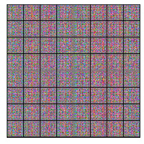

```python
fake = netG(fixed_noise).detach().cpu()
plt.imshow(np.transpose(utils.make_grid(fake, padding=2, normalize=True),(1,2,0)))
plt.xticks([])
plt.yticks([])
```

```python
dataloader = DataLoader(tensor_dataset, batch_size=64, shuffle=True)
```

```python
# Lists to keep track of progress
img_list = []
G_losses = []
D_losses = []
iters = 0
num_epochs = 1

print("Starting Training Loop...")
# For each epoch
for epoch in range(num_epochs):
    # For each batch in the dataloader
    for i, data in enumerate(dataloader, 0):
        ############################
        # (1) Update D network: maximize log(D(x)) + log(1 - D(G(z)))
        ###########################
        ## Train with all-real batch
        netD.zero_grad()
        # Format batch
        real_cpu = data.to(device)
        b_size = real_cpu.size(0)
        label = torch.full((b_size,), real_label, device=device)
        # Forward pass real batch through D
        output = netD(real_cpu).view(-1)
        # Calculate loss on all-real batch
        errD_real = criterion(output, label)
        # Calculate gradients for D in backward pass
        errD_real.backward()
        D_x = output.mean().item()

        ## Train with all-fake batch
        # Generate batch of latent vectors
        noise = torch.randn(b_size, nz, 1, 1, device=device)
        # Generate fake image batch with G
        fake = netG(noise)
        label.fill_(fake_label)
        # Classify all fake batch with D
        output = netD(fake.detach()).view(-1)
        # Calculate D's loss on the all-fake batch
        errD_fake = criterion(output, label)
        # Calculate the gradients for this batch
        errD_fake.backward()
        D_G_z1 = output.mean().item()
        # Add the gradients from the all-real and all-fake batches
        errD = errD_real + errD_fake
        # Update D
        optimizerD.step()

        ############################
        # (2) Update G network: maximize log(D(G(z)))
        ###########################
        netG.zero_grad()
        label.fill_(real_label)  # fake labels are real for generator cost
        # Since we just updated D, perform another forward pass of all-fake batch through D
        output = netD(fake).view(-1)
        # Calculate G's loss based on this output
        errG = criterion(output, label)
        # Calculate gradients for G
        errG.backward()
        D_G_z2 = output.mean().item()
        # Update G
        optimizerG.step()

        # Output training stats
        if i % 50 == 0:
            print('[%d/%d][%d/%d]\tLoss_D: %.4f\tLoss_G: %.4f\tD(x): %.4f\tD(G(z)): %.4f / %.4f'
                  % (epoch, num_epochs, i, len(dataloader),
                     errD.item(), errG.item(), D_x, D_G_z1, D_G_z2))

        # Save Losses for plotting later
        G_losses.append(errG.item())
        D_losses.append(errD.item())

        # Check how the generator is doing by saving G's output on fixed_noise
        if (iters % 500 == 0) or ((epoch == num_epochs-1) and (i == len(dataloader)-1)):
            with torch.no_grad():
                fake = netG(fixed_noise).detach().cpu()
            img_list.append(utils.make_grid(fake, padding=2, normalize=True))

        iters += 1
```

```python
from IPython.display import HTML
```

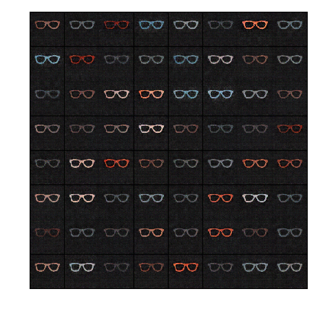

```python
# fig = plt.figure(figsize=(8,8))
# plt.axis("off")
# ims = [[plt.imshow(np.transpose(i,(1,2,0)), animated=False)] for i in img_list]
# img_list[-1].shape, ims[-1][0]

# pre-saved for demo
ims = plt.imread('data/present/img_list_eyeglasses.png')
fig = plt.figure(figsize=(8,8))
plt.axis("off")
plt.imshow(ims)
```

## Finetune Facial Recognition Network

```
project
│   README.md
│   AGN.ipynb
│
└───data
│   │   files_sample.csv
│   └───eyeglasses
│   │
│   └───test_me
│       └───train
|           └───Adrien_Brody
|           ...
|           └───Michael_Chaykowsky
|           ...
|           └───Venus_Williams
│       └───val
|           └───Adrien_Brody
|           ...
|           └───Michael_Chaykowsky
|           ...
|           └───Venus_Williams
│
└───models
    ...
```

### Load data

```python
# Data augmentation and normalization for training
# Just normalization for validation
data_transforms = {
    'train': transforms.Compose([
        transforms.RandomHorizontalFlip(),
        transforms.ToTensor(),
        transforms.Normalize([0.485, 0.456, 0.406], [0.229, 0.224, 0.225])
    ]),
    'val': transforms.Compose([
        transforms.ToTensor(),
        transforms.Normalize([0.485, 0.456, 0.406], [0.229, 0.224, 0.225])
    ]),
}

data_dir = 'data/test_me'
image_datasets = {x: datasets.ImageFolder(os.path.join(data_dir, x),
                                          data_transforms[x])
                  for x in ['train', 'val']}
dataloaders = {x: torch.utils.data.DataLoader(image_datasets[x], batch_size=8, # was 16
                                             shuffle=True)
              for x in ['train', 'val']}
dataset_sizes = {x: len(image_datasets[x]) for x in ['train', 'val']}
class_names = image_datasets['train'].classes
class_names
```

```
['Adrien_Brody',
 'Alejandro_Toledo',
 'Angelina_Jolie',
 'Carlos_Moya',
 'Charles_Moose',
 'James_Blake',
 'Jennifer_Lopez',
 'Michael_Chaykowsky',
 'Roh_Moo-hyun',
 'Venus_Williams']
```

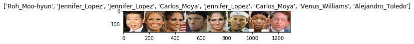

```python
def imshow(inp, title=None):
    """Imshow for Tensor."""
    inp = inp.numpy().transpose((1, 2, 0))
    mean = np.array([0.485, 0.456, 0.406])
    std = np.array([0.229, 0.224, 0.225])
    inp = std * inp + mean
    inp = np.clip(inp, 0, 1)
    plt.imshow(inp)
    if title is not None:
        plt.title(title)
    plt.pause(0.001)  # pause a bit so that plots are updated


# Get a batch of training data
inputs, classes = next(iter(dataloaders['train']))

# Make a grid from batch
out = utils.make_grid(inputs)

imshow(out, title=[class_names[x] for x in classes])
```

### Write train classifier function

```python
def train_model(model, criterion, optimizer, scheduler, num_epochs=25):
    since = time.time()
    FT_losses = []

    best_model_wts = copy.deepcopy(model.state_dict())
    best_acc = 0.0

    for epoch in range(num_epochs):
        print('Epoch {}/{}'.format(epoch, num_epochs - 1))
        print('-' * 10)

        # Each epoch has a training and validation phase
        for phase in ['train', 'val']:
            if phase == 'train':
                model.train()  # Set model to training mode
            else:
                model.eval()   # Set model to evaluate mode

            running_loss = 0.0
            running_corrects = 0

            # Iterate over data.
            for inputs, labels in dataloaders[phase]:
                inputs = inputs.to(device)
                labels = labels.to(device)
                #set_trace()

                # zero the parameter gradients
                optimizer.zero_grad()

                # forward
                # track history if only in train
                with torch.set_grad_enabled(phase == 'train'):
                    outputs = model(inputs)
                    #set_trace()
                    _, preds = torch.max(outputs, 1)
                    loss = criterion(outputs, labels)

                    # backward + optimize only if in training phase
                    if phase == 'train':
                        loss.backward()
                        optimizer.step()
                        scheduler.step()

                FT_losses.append(loss.item())
                # statistics
                running_loss += loss.item() * inputs.size(0)
                running_corrects += torch.sum(preds == labels.data)

            epoch_loss = running_loss / dataset_sizes[phase]
            epoch_acc = running_corrects.double() / dataset_sizes[phase]

            print('{} Loss: {:.4f} Acc: {:.4f}'.format(
                phase, epoch_loss, epoch_acc))

            # deep copy the model
            if phase == 'val' and epoch_acc > best_acc:
                best_acc = epoch_acc
                best_model_wts = copy.deepcopy(model.state_dict())

    time_elapsed = time.time() - since
    print('Training complete in {:.0f}m {:.0f}s'.format(
        time_elapsed // 60, time_elapsed % 60))
    print('Best val Acc: {:4f}'.format(best_acc))

    # load best model weights
    model.load_state_dict(best_model_wts)
    return model, FT_losses
```

### Get pretrained resnet on vggface2 dataset

```python
from models.inception_resnet_v1 import InceptionResnetV1

print('Running on device: {}'.format(device))

model_ft = InceptionResnetV1(pretrained='vggface2', classify=False, num_classes=len(class_names))
```

[output not shown]

#### Find where the last conv block is

```python
list(model_ft.children())[-6:]
```

```
[Block8(
   (branch0): BasicConv2d(
     (conv): Conv2d(1792, 192, kernel_size=(1, 1), stride=(1, 1), bias=False)
     (bn): BatchNorm2d(192, eps=0.001, momentum=0.1, affine=True, track_running_stats=True)
     (relu): ReLU()
   )
   (branch1): Sequential(
     (0): BasicConv2d(
       (conv): Conv2d(1792, 192, kernel_size=(1, 1), stride=(1, 1), bias=False)
       (bn): BatchNorm2d(192, eps=0.001, momentum=0.1, affine=True, track_running_stats=True)
       (relu): ReLU()
     )
     (1): BasicConv2d(
       (conv): Conv2d(192, 192, kernel_size=(1, 3), stride=(1, 1), padding=(0, 1), bias=False)
       (bn): BatchNorm2d(192, eps=0.001, momentum=0.1, affine=True, track_running_stats=True)
       (relu): ReLU()
     )
     (2): BasicConv2d(
       (conv): Conv2d(192, 192, kernel_size=(3, 1), stride=(1, 1), padding=(1, 0), bias=False)
       (bn): BatchNorm2d(192, eps=0.001, momentum=0.1, affine=True, track_running_stats=True)
       (relu): ReLU()
     )
   )
   (conv2d): Conv2d(384, 1792, kernel_size=(1, 1), stride=(1, 1))
 ),
 AdaptiveAvgPool2d(output_size=1),
 Linear(in_features=1792, out_features=512, bias=False),
 BatchNorm1d(512, eps=0.001, momentum=0.1, affine=True, track_running_stats=True),
 Linear(in_features=512, out_features=8631, bias=True),
 Softmax(dim=1)]
```

#### Remove the last layers after conv block

```python
layer_list = list(model_ft.children())[-5:]
```

```python
model_ft = nn.Sequential(*list(model_ft.children())[:-5])
```

```python
class Flatten(nn.Module):
    def __init__(self):
        super(Flatten, self).__init__()

    def forward(self, x):
        x = x.view(x.size(0), -1)
        return x
```

```python
class normalize(nn.Module):
    def __init__(self):
        super(normalize, self).__init__()

    def forward(self, x):
        x = F.normalize(x, p=2, dim=1)
        return x
```

Check resnet implementation for reason of reshaping in `last_linear` layer:

https://github.com/pytorch/vision/blob/3d5610391eaef38ae802ffe8b693ac17b13bd5d1/torchvision/models/resnet.py#L203

```python
## IF TRAINING JUST LAST LAYERS

for param in model_ft.parameters():
    param.requires_grad = False
```

#### Re-attach the last 5 layers which will set requires_grad = True automatically

- change the last layer to output the length of the `class_names`

```python
model_ft.avgpool_1a = nn.AdaptiveAvgPool2d(output_size=1)
model_ft.last_linear = nn.Sequential(
    Flatten(),
    nn.Linear(in_features=1792, out_features=512, bias=False),
    normalize()
)
model_ft.logits = nn.Linear(layer_list[3].in_features, len(class_names))
model_ft.softmax = nn.Softmax(dim=1)

model_ft = model_ft.to(device)

criterion = nn.CrossEntropyLoss()

# Observe that all parameters are being optimized
optimizer_ft = optim.SGD(model_ft.parameters(), lr=1e-2, momentum=0.9)

# Decay LR by a factor of *gamma* every *step_size* epochs
exp_lr_scheduler = lr_scheduler.StepLR(optimizer_ft, step_size=7, gamma=0.1)
```

```python
optimizer_ft = optim.SGD(model_ft.parameters(), lr=1e-2, momentum=0.5)
```

### Training

```python
model_ft, FT_losses = train_model(model_ft, criterion, optimizer_ft, exp_lr_scheduler, num_epochs=500)
```

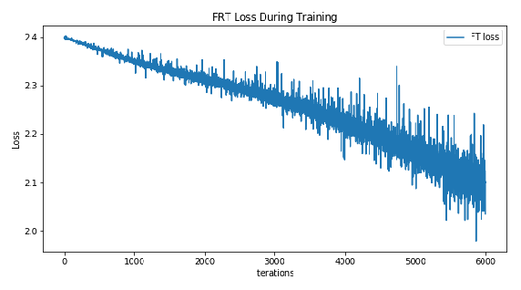

```python
# plt.figure(figsize=(10,5))
# plt.title("FRT Loss During Training")
# plt.plot(FT_losses,label="FT loss")
# plt.xlabel("iterations")
# plt.ylabel("Loss")
# plt.legend()
# plt.show()

# pre-saved for demo
ims = plt.imread('data/present/FRT_loss_decrease_500.png')
fig = plt.figure(figsize=(10,6))
plt.axis("off")
plt.imshow(ims)
```

```python
#torch.save({'state_dict': model_ft.state_dict()}, 'model_ft_acc100_09232019.pth.tar')
```

[figure not shown]

```python
#visualize_model(model_ft)

# plt.ioff()
# plt.show()

# pre-saved for demo
ims = plt.imread('data/present/frt_preds.png')
fig = plt.figure(figsize=(5,10))
plt.axis("off")
plt.imshow(ims)
```

## Pre-process AGN data

```python
! mkdir ~/Adversarial/data/Michael_Chaykowsky
```

### Get video(s) of facial expressions

```python
from IPython.display import Video

Video("data/IMG_2411.MOV", width=200, height=350)
```

[video not shown]

### Capture the frames of the video as `.png` files and rotate/crop/align

```python
vidcap = cv2.VideoCapture('IMG_2411.MOV')
success,image = vidcap.read()
count = 0
success = True
while success:
    cv2.imwrite(f"./Michael_Chaykowsky/Michael_Chaykowsky_{format(count, '04d')}.png", image)
    success,image = vidcap.read()
    print('Read a new frame: ', success)
    count += 1
```

Make sure to `brew install imagemagick` first

```python
%%!
for szFile in ./Michael_Chaykowsky/*.png
do
    magick mogrify -rotate 90 ./Michael_Chaykowsky/"$(basename "$szFile")" ;
done
```

`pip install autocrop`

```python
! autocrop -i ./me_orig/Michael_Chaykowsky -o ./me/Michael_Chaykowsky160 -w 720 -H 720 --facePercent 80
```

Directory must have subdirectory with name of person and images stored inside

- this is already done by the previous autocrop step

`! pip install tensorflow==1.13.0rc1`

`! pip install scipy==1.1.0`

Use the directory above the classes directory (not the actual directory holding the images)

```python
%%!
for N in {1..4}; do \
python ~/Adversarial/data/align/align_dataset_mtcnn.py \ # tensorflow script
~/Adversarial/data/me/ \ # current directory
~/Adversarial/data/me160/ \ # new directory
--image_size 160 \
--margin 32 \
--random_order \
--gpu_memory_fraction 0.25 \
& done
```

```python
with open('bboxes_fnames_test.csv', 'w') as f:
    writer = csv.writer(f)
    writer.writerows(zip(['filename']))
    a = [os.path.basename(x) for x in glob.glob('agn_me_extras160/Michael_Chaykowsky/*.png')]
    writer.writerows(zip(a))
```

### Custom dataset for images of my face to affix glasses

```python
class MeDataset(Dataset):
    """Me dataset."""

    def __init__(self, csv_file, root_dir, bs, transform_img=None, transform_land=None):
        """
        Args:
            csv_file (string): Path to the csv file with labels.
            root_dir (string): Directory with all the images.
            transform (callable, optional): Optional transform to be applied
                on a sample.
        """
        self.label = pd.read_csv(csv_file)
        self.root_dir = root_dir
        self.transform_img = transform_img
        self.transform_land = transform_land
        self.bs = bs

    def __len__(self):
        return len(self.label)

    def __getitem__(self, idx):
        img_name = os.path.join(self.root_dir,
                                self.label.iloc[idx, 0])
        image = io.imread(img_name)
        landmarks = self.label.iloc[idx, 1:]
        landmarks = np.array([landmarks])
        landmarks = landmarks.astype('float').reshape(-1, 2)
        sample = {'image': image, 'landmarks': landmarks, 'label': np.zeros(self.bs).astype('uint8').reshape(-1, 1)}

        if self.transform_img:
            sample['image'] = self.transform_img(sample['image'])

        if self.transform_land:
            sample['landmarks'] = self.transform_land(sample['landmarks'])
            sample['label'] = self.transform_land(sample['label'])

        return sample['image'], sample['landmarks'].reshape(-1), sample['label'].reshape(-1).view(-1)
```

```python
t_img = transforms.Compose([transforms.ToTensor()])
t_land = transforms.Compose([transforms.ToTensor()])
data_dir = 'data/me160'
image_datasets = MeDataset('data/bboxes_fnames.csv','data/agn_me_extras160/Michael_Chaykowsky',
                           bs = 1, transform_img=t_img, transform_land=t_land)
dataloader_me = torch.utils.data.DataLoader(image_datasets, batch_size=1, shuffle=False)
```

```python
data = next(iter(dataloader_me))
```

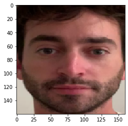

```python
plt.imshow(np.transpose(utils.make_grid(data[0], padding=2, normalize=True),(1,2,0)))
```

### `dlib` face alignment

```python
predictor_path = "data/shape_predictor_68_face_landmarks.dat"
face_rec_model_path = "data/dlib_face_recognition_resnet_model_v1.dat"

cnn_face_detector = dlib.cnn_face_detection_model_v1("data/mmod_human_face_detector.dat")
detector = dlib.get_frontal_face_detector()
predictor = dlib.shape_predictor(predictor_path)
```

#### Capture the specific areas of the face around the eyes and save to list

```python
coords = []
for frame, _, labels in dataloader_me:
    print(frame[0].shape)
    frame = np.transpose(to_np(frame[0]), (1,2,0)) * 255
    frame = frame.astype('uint8')
    #frame = cv2.cvtColor(frame, cv2.COLOR_BGR2RGB)
    print(frame.shape)
    dets = cnn_face_detector(frame, 1)
    d = dets[0]
    shape = predictor(frame, d.rect)

    glassWidth = abs(shape.part(16).x - shape.part(1).x)
    glassHeight = int(glassWidth * origGlassHeight / origGlassWidth)

    y1 = int(shape.part(24).y)
    y2 = int(y1 + glassHeight)
    x1 = int(shape.part(27).x - (glassWidth/2))
    x2 = int(x1 + glassWidth)

    if y1 < 0:
        glassHeight = glassHeight - abs(y1)
        y1 = 0
    if y2 > frame.shape[0]: glassHeight = glassHeight - (y2 - frame.shape[0])
    if x1 < 0:
        glassWidth = glassWidth - abs(x1)
        x1 = 0
    if x2 > frame.shape[1]: glassWidth = glassWidth - (x2 - frame.shape[1])

    coords.append([x1, x2, y1, y2, glassHeight, glassWidth])
```

```python
pd.concat([
    pd.read_csv('data/bboxes_fnames.csv'),
    pd.DataFrame(coords, columns=['x1','x2','y1','y2','h','w'])],
    axis=1).to_csv('data/bboxes_fnames.csv', index=False)
```

## AGN training

### Load pre-trained facial recognition classifier

```python
# checkpoint = torch.load('data/tmp/model_ft_acc98_09202019.pth.tar',map_location='cpu')
# model_ft.load_state_dict(checkpoint['state_dict'])
```

[output not shown]

```python
model_ft = model_ft.to(device)
```

### Load dataset of my faces for building adversarial examples during training

```python
t_img = transforms.Compose([
    transforms.ToPILImage(),
    transforms.ColorJitter(brightness=0.1, contrast=0.1, saturation=0.1),
    #transforms.RandomHorizontalFlip(),
    #transforms.RandomRotation(5),
    transforms.ToTensor(),
    transforms.Normalize((0.485, 0.456, 0.406), (0.229, 0.224, 0.225))
])

t_landmarks = transforms.Compose([
    transforms.ToTensor()
])

data_dir = 'data/agn_me'
#image_datasets_me = datasets.ImageFolder(data_dir, data_transforms)
image_datasets_me = MeDataset('data/bboxes_fnames.csv', 'data/agn_me_extras160/Michael_Chaykowsky',
                           bs = 1, transform_img=t_img, transform_land=t_landmarks)

# FIGURE OUT WHY THIS WON'T WORK FOR SHUFFLE = FALSE #
dataloader_me = torch.utils.data.DataLoader(image_datasets_me, batch_size=64, shuffle=True)
```

```python
imgGlass = cv2.imread("data/glasses_mask.png", -1)
#imgGlass = cv2.cvtColor(imgGlass, cv2.COLOR_BGR2RGB)
r = 160.0 / imgGlass.shape[1]
dim = (160, int(imgGlass.shape[0] * r))
imgGlass = cv2.resize(imgGlass, dim, interpolation = cv2.INTER_AREA)

imgGlass = imgGlass[39:81, 21:138]
alpha_data = imgGlass[:,:,0] + imgGlass[:,:,1] + imgGlass[:,:,2]
alpha_data[alpha_data < 200] = 0
alpha_data[alpha_data > 20] = 255

orig_mask_g = alpha_data
orig_mask_inv_g = cv2.bitwise_not(orig_mask_g)

orig_mask_g = orig_mask_g / 255
orig_mask_inv_g = orig_mask_inv_g / 255
```

```python
def unorm_glasses(fake):
    return (fake - fake.min())/(fake.max() - fake.min())
```

```python
unorm = UnNormalize(mean=(0.485, 0.456, 0.406), std=(0.229, 0.224, 0.225))
renorm = Normalize(mean=(0.485, 0.456, 0.406), std=(0.229, 0.224, 0.225))
```

```python
images, landmarks, labels = next(iter(dataloader_me))
for i in range(images.size(0)):
    img = images[i,:,:,:]
    img = to_np(unorm(img))
    img = np.transpose(img, (1,2,0)) * 255
    img = img.astype('uint8')
    glassHeight,glassWidth = to_np(landmarks[i,-2:]).astype('uint8')
    x1,x2,y1,y2 = to_np(landmarks[i,:-2]).astype('uint8')
    glass = cv2.resize(imgGlass, (glassWidth,glassHeight), interpolation = cv2.INTER_AREA)
    mask = cv2.resize(orig_mask_g, (glassWidth,glassHeight), interpolation = cv2.INTER_AREA)
    mask_inv = cv2.resize(orig_mask_inv_g, (glassWidth,glassHeight), interpolation = cv2.INTER_AREA)
    roi1 = img[y1:y2, x1:x2]
    roi_bg = cv2.bitwise_and(roi1,roi1,mask_inv)
    roi_fg = cv2.bitwise_and(glass,glass,mask)
    img[y1:y2, x1:x2] = cv2.add(roi_bg, roi_fg)
    images[i,:,:,:] = T(np.transpose(img, (2,0,1)) / 255)
```

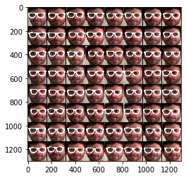

```python
plt.imshow(np.transpose(utils.make_grid(images, padding=2, normalize=True),(1,2,0)))
```

```python
# checkpoint = torch.load('AGN_G_09272019_nomax_3.pth.tar')
# netG.load_state_dict(checkpoint['state_dict'])
```

[output not shown]

```python
# checkpoint = torch.load('AGN_D_09272019_nomax_3.pth.tar')
# netD.load_state_dict(checkpoint['state_dict'])
```

[output not shown]

```python
#torch.cuda.memory_allocated()
#torch.cuda.empty_cache()
#torch.cuda.memory_cached()
```

### Carlini-Wagner Loss

```python
def CWLoss(logits, target, b_size, is_targeted, num_classes=None, kappa=0):
    # inputs to the softmax function are called logits.
    # https://arxiv.org/pdf/1608.04644.pdf
    #set_trace()
    target_one_hot = torch.eye(num_classes).type(logits.type())[target.long()]
    logits = torch.log(logits / (1 - logits))
    #logits = torch.log(logits)
    # https://github.com/carlini/nn_robust_attacks/blob/master/l2_attack.py
    real = torch.sum(target_one_hot*logits, 1)
    other = torch.max((1-target_one_hot)*logits - (target_one_hot*10000), 1)[0]
    kappa = torch.zeros_like(other).fill_(kappa)

    if is_targeted:
        return torch.sum(torch.max(other-real, kappa))
    return torch.sum(real-other)
```

```python
def train_AGN(netG, netD, model_ft, dataloader, dataloader_me,
              orig_mask_inv_g, class_names, num_epochs:int=10, kap:float=0.2):
    # Initialize BCEWithLogitsLoss function (better to use without softmax on end)
    criterion = nn.BCEWithLogitsLoss()
    criterionCW = CWLoss

    # Create batch of latent vectors that we will use to visualize
    #  the progression of the generator
    fixed_noise = torch.randn(64, nz, 1, 1, device=device)

    # Establish convention for real and fake labels during training
    real_label = 1
    fake_label = 0
    me_label = [i for i, el in enumerate(class_names) if el == 'Michael_Chaykowsky'][0]
    print('me_label: ', me_label)

    beta1 = 0.5

    # Setup Adam optimizers for both G and D
    optimizerD = optim.Adam(netD.parameters(), lr=5e-6, betas=(beta1, 0.99))
    optimizerG = optim.Adam(netG.parameters(), lr=5e-6, betas=(beta1, 0.99))
    # Lists to keep track of progress
    img_list = []
    G_losses = []
    D_losses = []
    d1s = []
    d3s = []
    num_fooled = []
    iters = 0
    counter = 0

    # torch.autograd.set_detect_anomaly(True)
    for p in netG.parameters():
        p.register_hook(lambda grad: print(torch.norm(grad)))
        break

    print("Starting Training Loop...")
    # For each epoch
    for epoch in range(num_epochs):
        # For each batch in the dataloader
        for i, data in enumerate(dataloader):
            if data.shape[0] != 64: continue
            ############################
            # (1) Update D network: maximize log(D(x)) + log(1 - D(G(z)))
            ###########################
            ## Train with all-real batch
            netD.zero_grad()
            # Format batch
            real_cpu = data.to(device)
            b_size = real_cpu.size(0)
            label = torch.full((b_size,), real_label, device=device)
            # Forward pass real batch through D
            output = netD(real_cpu).view(-1)
            # Calculate loss on all-real batch
            errD_real = criterion(output, label)
            # Calculate gradients for D in backward pass
            errD_real.backward()
            D_x = output.mean().item()

            ## Train with all-fake batch
            # Generate batch of latent vectors
            noise = torch.randn(b_size, nz, 1, 1, device=device)
            # Generate fake image batch with G
            fake = netG(noise)
            label.fill_(fake_label)
            # Classify all fake batch with D
            output = netD(fake.detach()).view(-1)
            # Calculate D's loss on the all-fake batch
            errD_fake = criterion(output, label)
            # Calculate the gradients for this batch
            errD_fake.backward()
            D_G_z1 = output.mean().item()
            # Add the gradients from the all-real and all-fake batches
            errD = errD_real + errD_fake
            # Update D
            optimizerD.step()

            ############################
            # (3) Check if F(.) is fooled
            ###########################
            # Get a batch of faces
            model_ft.eval()
            fakes = unorm_glasses(fake)
            fakes = fakes[:,:,39:81,21:138]
            for j in range(fakes.size(0)):
                for k in range(fakes.size(1)):
                    fakes[j,k,:,:][orig_mask_g == 0] = 0
            faces, landmarks, labels = next(iter(dataloader_me))
            for j in range(faces.size(0)):
                img = unorm(faces[j,:,:,:]).cpu()
                glassHeight,glassWidth = landmarks[j,-2:].int()
                x1,x2,y1,y2 = landmarks[j,:-2].int()
                glass = F.interpolate(fakes, (glassHeight,glassWidth)).cpu()
                mask = F.interpolate(T(orig_mask_g[None,None,:,:]), (glassHeight,glassWidth))
                mask_inv = F.interpolate(T(orig_mask_inv_g[None,None,:,:]), (glassHeight,glassWidth))
                roi1 = img[None,:,y1:y2, x1:x2]
                roi_bg = roi1 - mask
                roi_bg = torch.clamp(roi_bg, 0)
                roi_fg = glass + mask_inv
                img[:,y1:y2, x1:x2] = glass[j] + roi_bg[0]
                faces[j,:,:,:] = img
            faces = renorm(faces).to(device)
            with torch.no_grad():
                outputs = model_ft(faces)
                _, preds = torch.max(outputs, 1)
                if i % 100 == 0: img_list.append(utils.make_grid(faces.detach().cpu(), padding=2, normalize=True))
                print('Num Fooled: ', torch.sum(preds != me_label).item(),
                      'Sum prob me: ', outputs[:,me_label].sum().item(),
                      'Sum prob targ: ', outputs[:,7].sum().item())
                if torch.all(preds != me_label):
                    return netG, img_list, G_losses, D_losses, d1s, d3s, num_fooled

            ############################
            # (3) Update G network
            ###########################
            netG.zero_grad()
            label.fill_(real_label)  # fake labels are real for generator cost
            # Since we just updated D, perform another forward pass of all-fake batch through D
            output = netD(fake).view(-1)
            # Calculate G's loss based on this output
            d1 = criterion(output, label)
            d1.backward(retain_graph=True)
            print(d1.item())

            # Take faces with glasses and forward pass through F()
            # Xsb = faces.to(device)
            labelXsb = torch.full((b_size,), me_label, device=device)    # CW Loss Label
            outputs = model_ft(faces)
            d3 = criterionCW(outputs, labelXsb, b_size, is_targeted=False, num_classes=len(class_names))
            d3.backward()
            print(d3.item())

            errG = d1 + d3

            # Other way to do backward pass
            # errG.backward()

            # Update G
            optimizerG.step()
            D_G_z2 = output.mean().item()

            # Output training stats
            if i % 100 == 0:
                print('[%d/%d][%d/%d]\tLoss_D: %.4f\tLoss_G: %.4f\tD(x): %.4f\tD(G(z)): %.4f / %.4f'
                      % (epoch, num_epochs, i, len(dataloader),
                         errD.item(), errG.item(), D_x, D_G_z1, D_G_z2))

            # Save Losses for plotting later
            G_losses.append(errG.item())
            D_losses.append(errD.item())
            d1s.append(d1.item())
            d3s.append(d3.item())
            num_fooled.append(torch.sum(preds != me_label).item())

            if iters == 20:
                return netG, img_list, G_losses, D_losses, d1s, d3s, num_fooled

            # Check how the generator is doing by saving G's output on fixed_noise
            if (iters % 1000 == 0) or ((epoch == num_epochs-1) and (i == len(dataloader)-1)):
                with torch.no_grad():
                    fake = netG(fixed_noise).detach().cpu()
                img_list.append(utils.make_grid(fake, padding=2, normalize=True))

            iters += 1
    return netG, img_list, G_losses, D_losses, d1s, d3s, num_fooled
```

```python
netG, img_list, G_losses, D_losses, d1s, d3s, num_fooled = train_AGN(netG, netD, model_ft,
                                                                     dataloader, dataloader_me,
                                                                     orig_mask_inv_g,
                                                                     class_names, num_epochs=1)
```

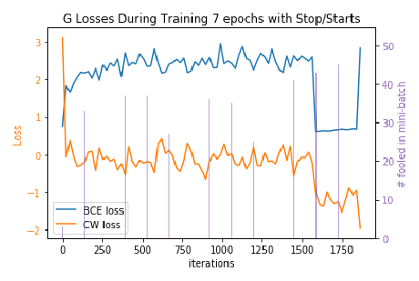

```python
# pre-saved for demo
ims = plt.imread('data/present/g_losses_agn.png')
fig = plt.figure(figsize=(8,8))
plt.axis("off")
plt.imshow(ims)
```

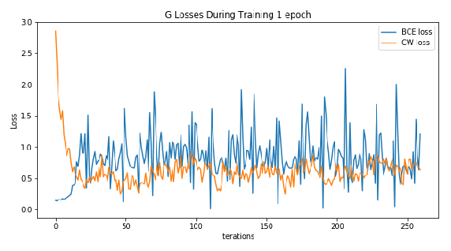

```python
# pre-saved for demo
ims = plt.imread('data/present/g_losses_agn_1epoch.png')
fig = plt.figure(figsize=(10,6))
plt.axis("off")
plt.imshow(ims)
```

### Test out resulting netG

```python
fixed_noise = torch.randn(1, nz, 1, 1, device=device)
fake = netG(fixed_noise).detach().cpu()
```

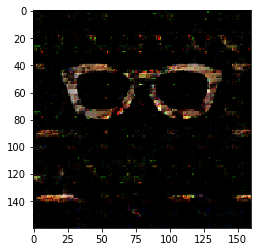

```python
plt.imshow(np.transpose(utils.make_grid(fake, padding=2, normalize=True),(1,2,0)))
```

```python
dataloader_me_test = torch.utils.data.DataLoader(image_datasets_me, batch_size=1, shuffle=True)
```

```python
fakes = unorm_glasses(fake)
fakes = fakes[:,:,39:81,21:138]
for k in range(3):
    fakes[0,k,:,:][orig_mask_g == 0] = 0
faces, landmarks, labels = next(iter(dataloader_me_test))
for j in range(faces.size(0)):
    img = unorm(faces[j,:,:,:]).cuda()
    glassHeight,glassWidth = landmarks[j,-2:].int()
    x1,x2,y1,y2 = landmarks[j,:-2].int()
    glass = F.interpolate(fakes, (glassHeight,glassWidth)).cuda()
    mask = F.interpolate(T(orig_mask_g[None,None,:,:]), (glassHeight,glassWidth))
    mask_inv = F.interpolate(T(orig_mask_inv_g[None,None,:,:]), (glassHeight,glassWidth))
    roi1 = img[None,:,y1:y2, x1:x2]
    roi_bg = roi1 - mask
    roi_bg = torch.clamp(roi_bg, 0)
    roi_fg = glass + mask_inv
    print(glass.shape, roi_bg[0].shape, img[:,y1:y2, x1:x2].shape)
    img[:,y1:y2, x1:x2] = glass[j] + roi_bg[0]
    faces[j,:,:,:] = img
```

```
torch.Size([1, 3, 51, 144]) torch.Size([3, 51, 144]) torch.Size([3, 51, 144])
```

[figure not shown]

```python
plt.imshow(np.transpose(utils.make_grid(faces.cpu(), padding=2, normalize=True),(1,2,0)))
```

```python
model_ft.eval()
faces = faces.to(device)
outputs = model_ft(faces)
_, preds = torch.max(outputs, 1)
print([class_names[p] for p in preds])
```

```
['Jennifer_Lopez']
```